# Datos hidrologicos

# Analisis de datos de las cuencas Estrella y Banano

A continuación se presenta un analisis explorativo de las estaciones Pandora y Banano, los cuales comprenden los ríos Estrella y Banano, por lo cual el siguiente estudio tiene como objetivo determinar las relaciones entre ambos caudales, así como tambien el volumen de las cuencas en un enfoque diario, mensual y anual.

Aquí se presentan algunos de los datos, dimensiones que nos fueron proporcionados para realizar dicho analisis.

```
##      Tiempo Pandora.mm..637km2. Banano.mm..90km2.
## 1 6/22/1973                7.46             21.02
## 2 6/23/1973                6.17             14.78
## 3 6/24/1973                6.32             27.65
## 4 6/25/1973                7.80             19.68
## 5 6/26/1973                7.72             15.17
## 6 6/27/1973                7.83             23.14
```

```
## [1] Tiempo              Pandora.mm..637km2. Banano.mm..90km2.
## <0 rows> (or 0-length row.names)
```

##Datos Hidrológicos relacionados con las series de tiempo de Caudal. Con respecto a las series de tiempo de Caudal, se aprecia en el siguiente gráfico, que el río Banano así como tambien el río estrella, tienen unos picos altos en un tiempo determinado, especificamente por que pertecen a la zona del caribe, por lo tanto su volumen tiene a aumentar con más facilidad con respecto a otros ríos del país.

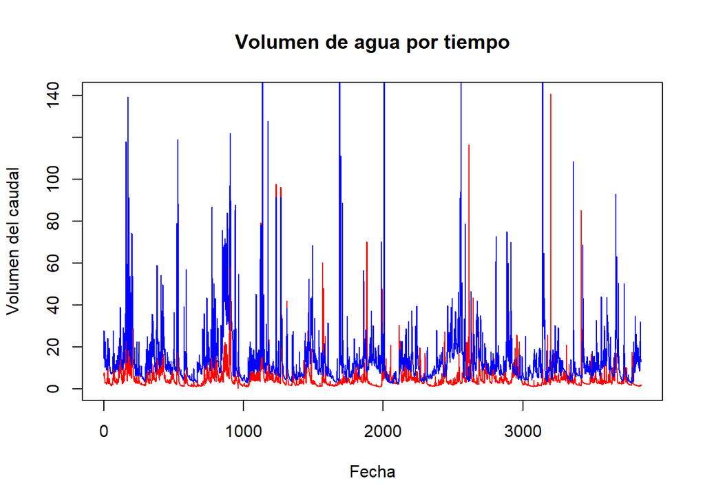

## Promedio de los caudales diarios.

Aquí se obtiene un analisis más detallado sobre el promedio de las cuencas, se evidencia los siguientes histogramas, como el promedio hidrico diario del río Banano es superior, en comparacion con el río Estrella.

```
##  Pandora.mm..637km2. Banano.mm..90km2.
##  Min.   :  0.180     Min.   :  2.43
##  1st Qu.:  2.390     1st Qu.:  6.88
##  Median :  3.590     Median : 10.18
##  Mean   :  5.459     Mean   : 14.28
##  3rd Qu.:  5.900     3rd Qu.: 15.46
##  Max.   :140.650     Max.   :384.00
```

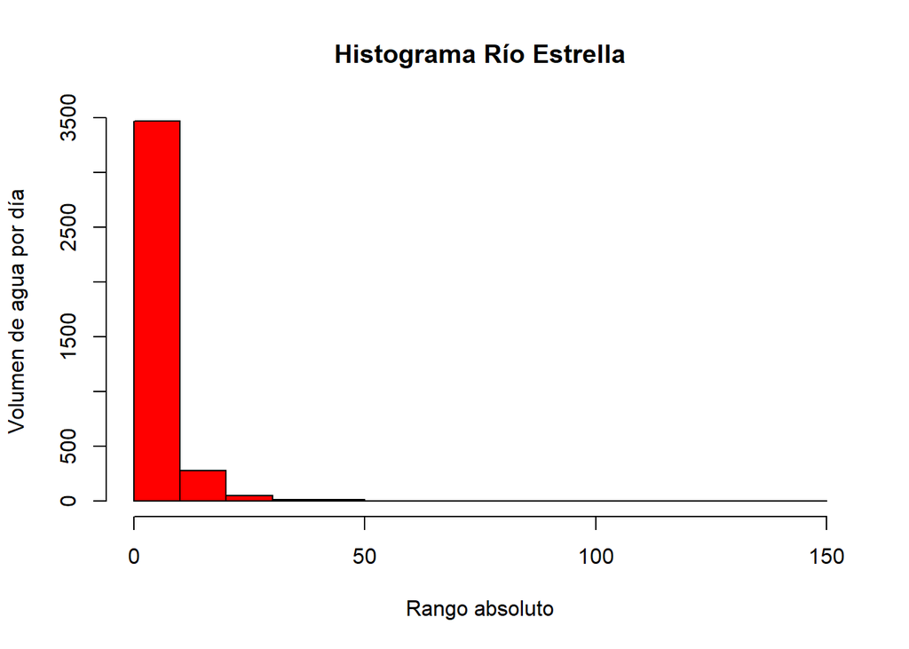

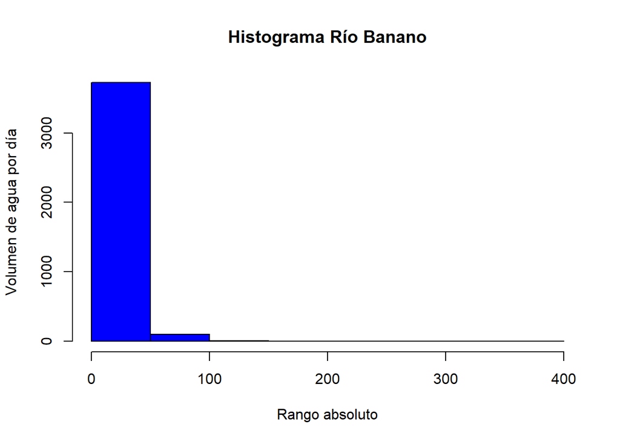

#Analisis de datos hidrologicos temporales

### Caudal Anual

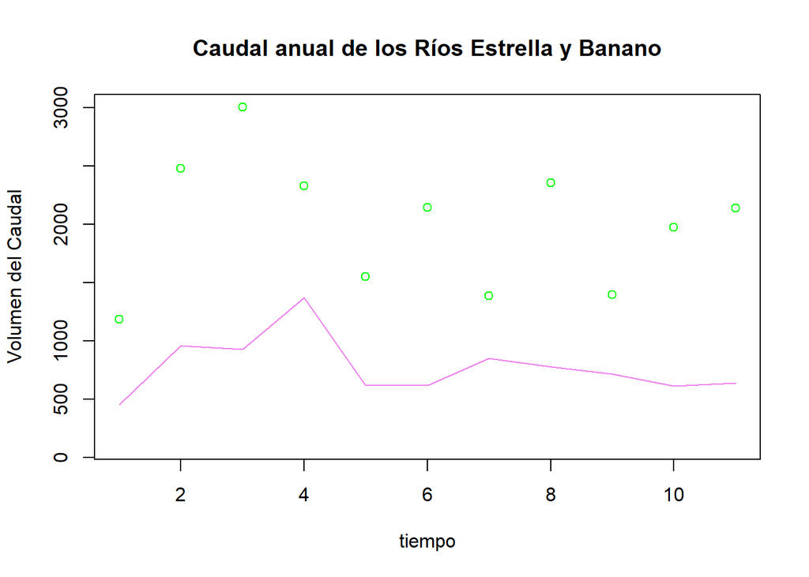

### Caudal mensual de datos hidrologicos

De igual manera como en la sección anterior,el río estrella presenta menores niveles de agua mensuales en relacion con el río Banano, sin embargo es importante señalar que en ambas cuencas el rango de los niveles de agua de forma mensual no difieren en gran medida. .

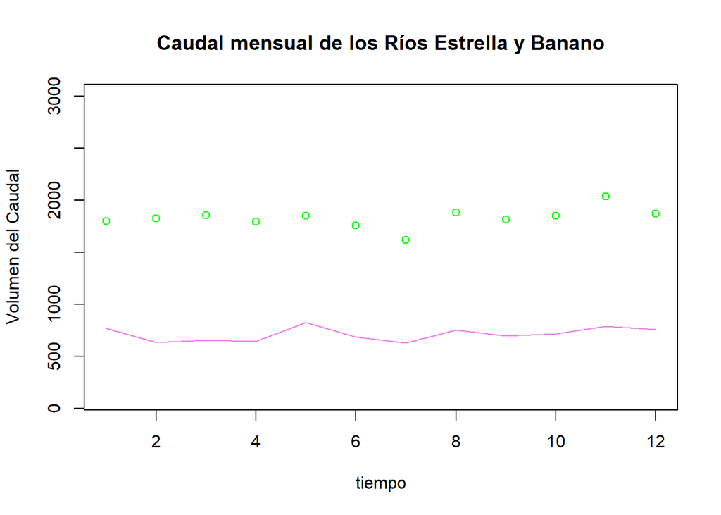

# Analisis de correlación

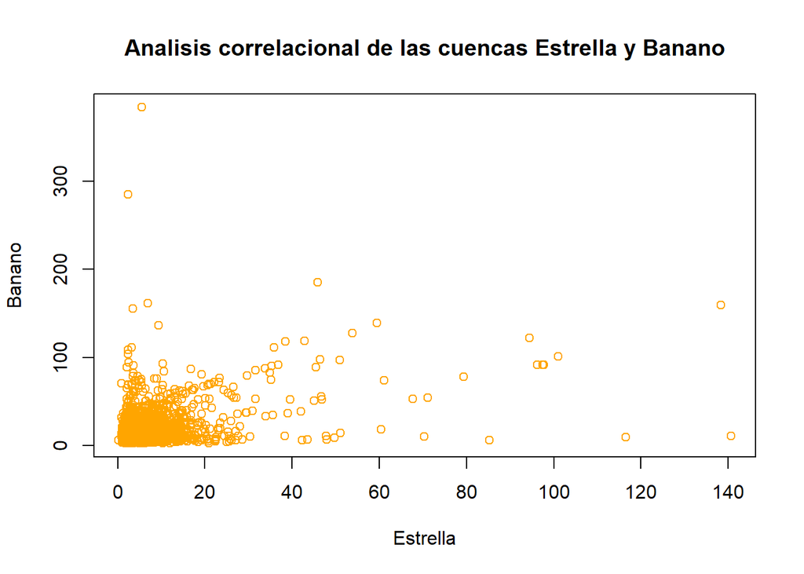

# Modelo de regresion lineal de los datos hidrologicos

Aquí se presentan una serie de diagnosticos, sobre la regresion lineal de las cuencas Banano y Estrella.

```
##
## Call:
## lm(formula = inp[, 2] ~ inp[, 3], data = inp)
##
## Residuals:
##     Min      1Q  Median      3Q     Max
## -71.297  -2.267  -1.155   0.774 135.889
##
## Coefficients:
##             Estimate Std. Error t value Pr(>|t|)
## (Intercept)  2.70503    0.15174   17.83   <2e-16 ***
## inp[, 3]     0.19290    0.00707   27.28   <2e-16 ***
## ---
## Signif. codes:  0 '***' 0.001 '**' 0.01 '*' 0.05 '.' 0.1 ' ' 1
##
## Residual standard error: 7.025 on 3843 degrees of freedom
## Multiple R-squared:  0.1623, Adjusted R-squared:  0.162
## F-statistic: 744.4 on 1 and 3843 DF,  p-value: < 2.2e-16
```

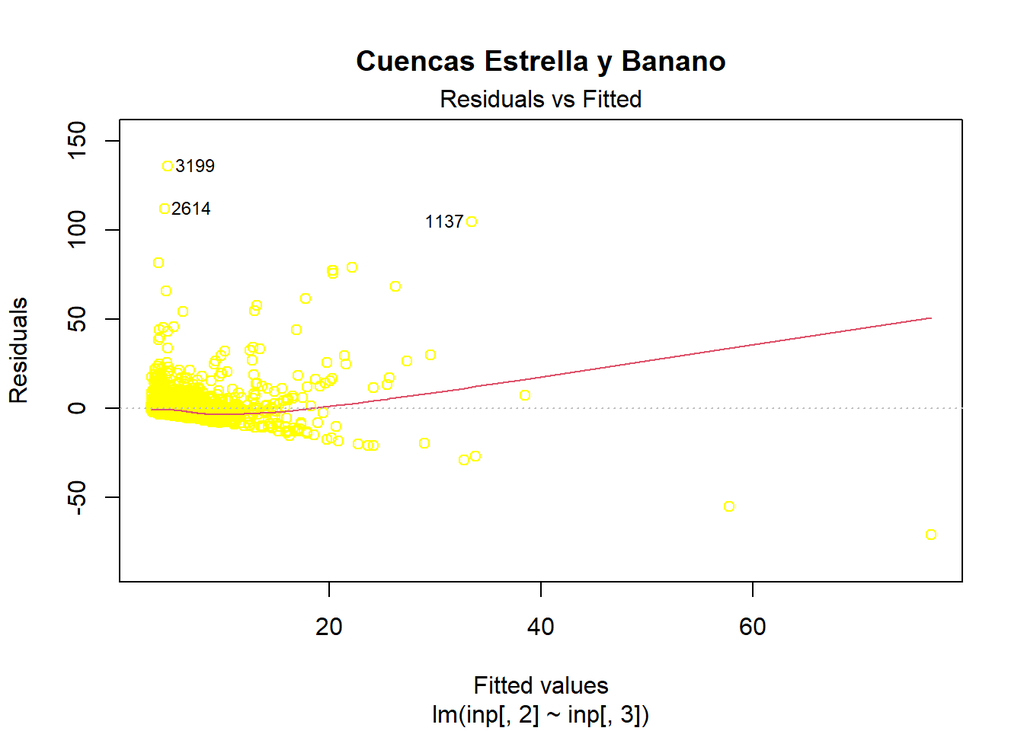

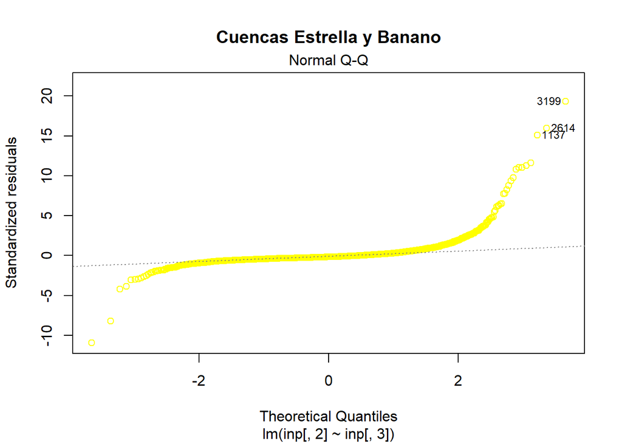

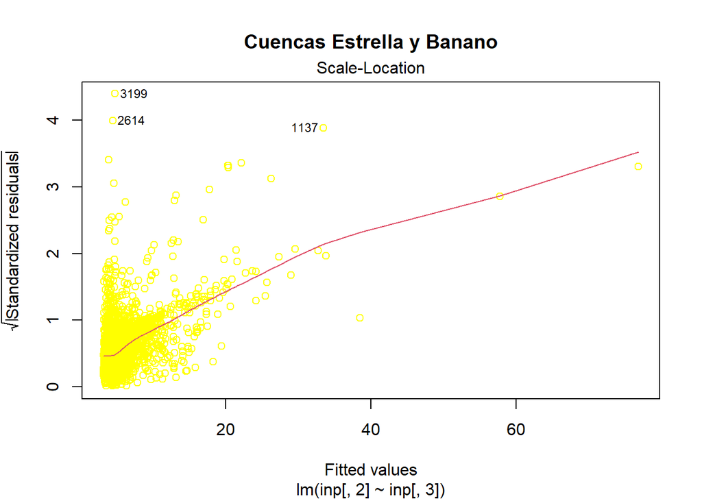

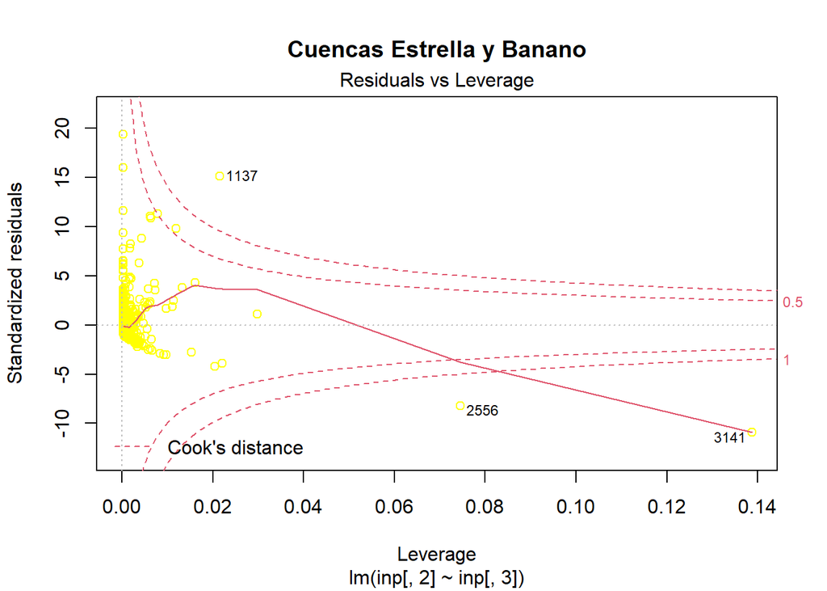